# Melbourne Real Estate Reviews

##### By Jason Ji

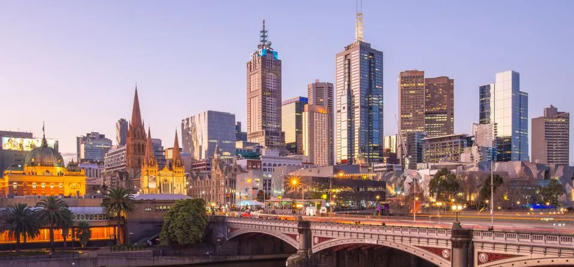

## Index

0. Data Preparation  
1.0 Market Share  
1.1 Total Sales by Value (Top 10)  
1.2 Total Sales by Number (Top 10)  
2. Sales Trend Over Time (Top 10)  
3. Sales Methods and Property Type  
3.1 Selling Method (Top 10)  
3.2 Property Type (Top 10)  
4. Property Prices  
4.1 Price Distribution (Top 10)  
4.2 Price vs. Distance  
5. Heatmaps  
6.0 Performance Analysis and Conclusions  
6.1 Conclusions

## 0. Data Preparation

### 0.1 Load the Data

```
The original dataset has 18396 observations
```

|  | Unnamed: 0 | Suburb | Address | Rooms | Type | Price | Method | SellerG | Date | Distance | ... | Bathroom | Car | Landsize | BuildingArea | YearBuilt | CouncilArea | Lattitude | Longtitude | Regionname | Propertycount |
| --- | --- | --- | --- | --- | --- | --- | --- | --- | --- | --- | --- | --- | --- | --- | --- | --- | --- | --- | --- | --- | --- |
| 0 | 1 | Abbotsford | 85 Turner St | 2 | h | 1480000 | S | Biggin | 3/12/2016 | 2.5 | ... | 1.0 | 1.0 | 202.0 | NaN | NaN | Yarra | -37.7996 | 144.9984 | Northern Metropolitan | 4019.0 |
| 1 | 2 | Abbotsford | 25 Bloomburg St | 2 | h | 1035000 | S | Biggin | 4/02/2016 | 2.5 | ... | 1.0 | 0.0 | 156.0 | 79.0 | 1900.0 | Yarra | -37.8079 | 144.9934 | Northern Metropolitan | 4019.0 |
| 2 | 4 | Abbotsford | 5 Charles St | 3 | h | 1465000 | SP | Biggin | 4/03/2017 | 2.5 | ... | 2.0 | 0.0 | 134.0 | 150.0 | 1900.0 | Yarra | -37.8093 | 144.9944 | Northern Metropolitan | 4019.0 |
| 3 | 5 | Abbotsford | 40 Federation La | 3 | h | 850000 | PI | Biggin | 4/03/2017 | 2.5 | ... | 2.0 | 1.0 | 94.0 | NaN | NaN | Yarra | -37.7969 | 144.9969 | Northern Metropolitan | 4019.0 |
| 4 | 6 | Abbotsford | 55a Park St | 4 | h | 1600000 | VB | Nelson | 4/06/2016 | 2.5 | ... | 1.0 | 2.0 | 120.0 | 142.0 | 2014.0 | Yarra | -37.8072 | 144.9941 | Northern Metropolitan | 4019.0 |

5 rows × 22 columns

### 0.2 Check for missing values

```
Missing Values:
BuildingArea: 57.81%
YearBuilt: 51.30%
CouncilArea: 33.50%
Landsize: 26.05%
Car: 19.44%
Bathroom: 18.87%
Bedroom2: 18.86%
Longtitude: 18.11%
Lattitude: 18.11%
Propertycount: 0.01%
Distance: 0.01%
Postcode: 0.01%
Regionname: 0.01%
Date: 0.00%
SellerG: 0.00%
Method: 0.00%
Price: 0.00%
Type: 0.00%
Rooms: 0.00%
Address: 0.00%
Suburb: 0.00%
Unnamed: 0: 0.00%
```

### 0.3 Check Duplicate values

```
Duplicate Entries:
0
```

### 0.4 Select useful columns

### 0.5 Describe the selected data

|  | Price | Distance | Postcode | Propertycount |
| --- | --- | --- | --- | --- |
| count | 18396.00 | 18395.00 | 18395.00 | 18395.00 |
| mean | 1056697.46 | 10.39 | 3107.14 | 7517.98 |
| std | 641921.67 | 6.01 | 95.00 | 4488.42 |
| min | 85000.00 | 0.00 | 3000.00 | 249.00 |
| 25% | 633000.00 | 6.30 | 3046.00 | 4294.00 |
| 50% | 880000.00 | 9.70 | 3085.00 | 6567.00 |
| 75% | 1302000.00 | 13.30 | 3149.00 | 10331.00 |
| max | 9000000.00 | 48.10 | 3978.00 | 21650.00 |

### 0.6 Extract the Date

## 1.0 Market Share

```
┌───────────────┬──────────────┬──────────────────────┬─────────────────┬─────────────────────┐
│    SellerG    │ Total_Number │ Percentage_of_number │ Total_Sales_AUD │ Percentage_of_Value │
│    varchar    │    int64     │        double        │     int128      │       double        │
├───────────────┼──────────────┼──────────────────────┼─────────────────┼─────────────────────┤
│ Jellis        │         1759 │                  9.6 │      2383028598 │                12.3 │
│ Nelson        │         2002 │                 10.9 │      1992624788 │                10.3 │
│ Marshall      │          887 │                  4.8 │      1695939138 │                 8.7 │
│ hockingstuart │         1580 │                  8.6 │      1485243749 │                 7.6 │
│ Barry         │         1390 │                  7.6 │      1192982264 │                 6.1 │
│ Buxton        │          939 │                  5.1 │      1140965035 │                 5.9 │
│ Ray           │         1032 │                  5.6 │       880563562 │                 4.5 │
│ Fletchers     │          403 │                  2.2 │       520323501 │                 2.7 │
│ Biggin        │          496 │                  2.7 │       493375900 │                 2.5 │
│ Woodards      │          411 │                  2.2 │       425039221 │                 2.2 │
├───────────────┴──────────────┴──────────────────────┴─────────────────┴─────────────────────┤
│ 10 rows                                                                           5 columns │
└─────────────────────────────────────────────────────────────────────────────────────────────┘
```

### 1.1 Total Sales by Value (Top 10)

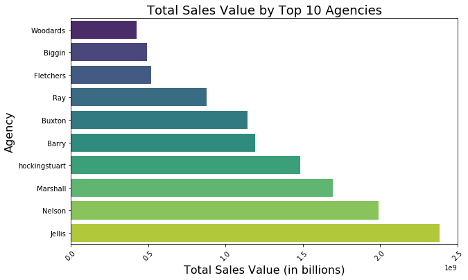

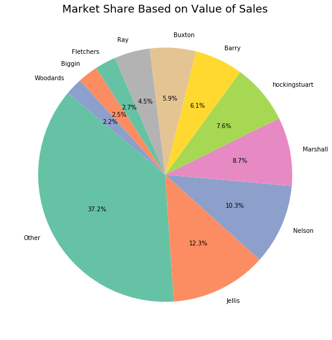

**Summary**:The top 10 agencies account for **62.8%** of the total value sales.

### 1.2 Total Sales by Number (Top 10)

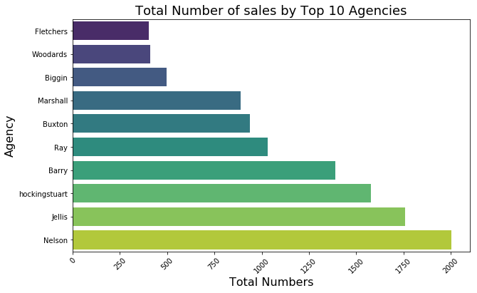

[figure not shown]

**Summary**:The top 10 agencies account for **59.2%** of the total number sales.

## 2. Sales Trend

### 2.1 Sales Trend Over Time (AUD)

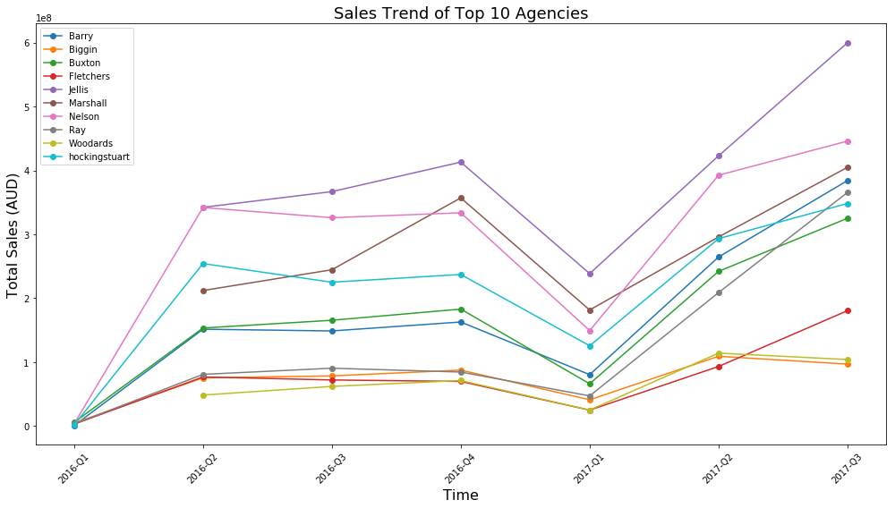

**Summary**:Q1 is the least active season for the real estate market. The top 3 agencies in the market are Jellis, Nelson and Marshall.

### 2.2 Sales Trend Over Time (Numbers)

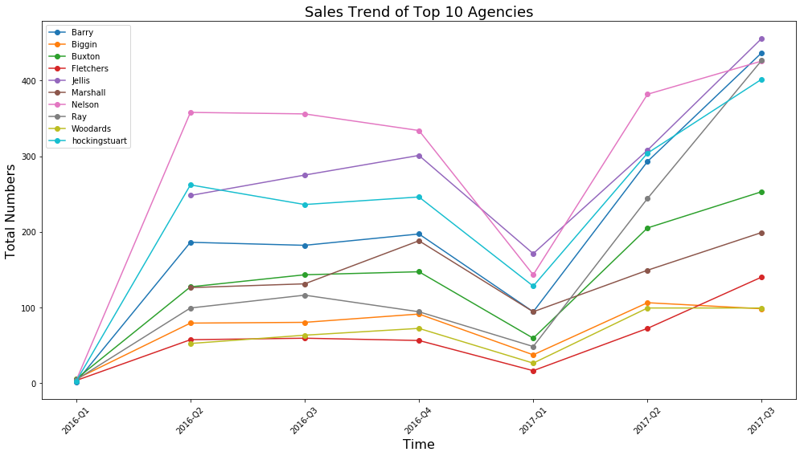

## 3. Sales Methods and Property Type

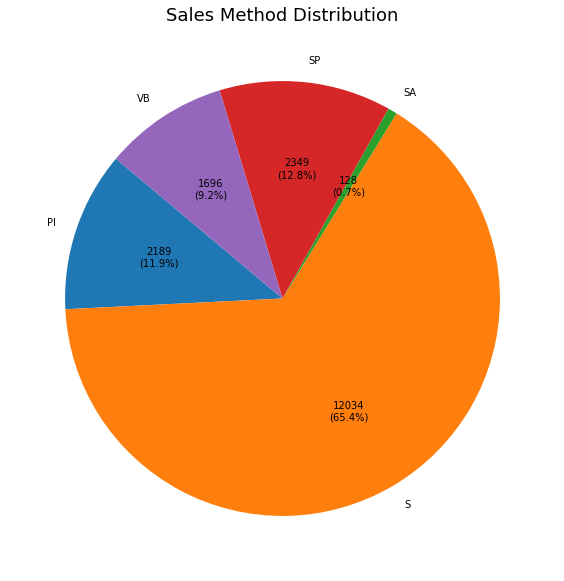

**Summary**: - The majority of sales are completed with the 'S-Sold' method (65.4%), indicating successful sales without prior offers or passing in at auctions. The 'SP-Sold Prior' and 'PI-Passed In' also represent significant portions, suggesting strategies like accepting offers before auctions or offer private negotiations are also common practices.

### 3.1 Selling Method (Top 10)

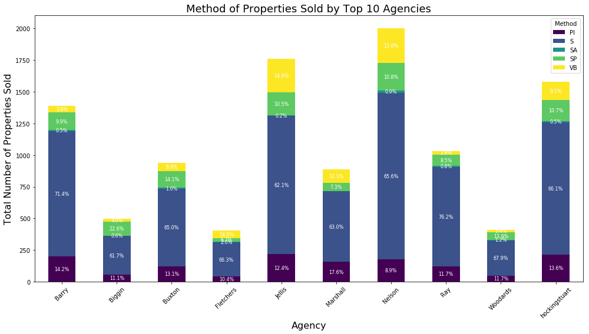

**Summary**:Specific sale method were favored by individual agencies (e.g., **Marshall** relys more on PI-Passed In, **Jellis** relys more on VB-Vendor Bid, **Ray** and **Barry** relys more on direct sales, etc.).

### 3.2 Property Type (Top 10)

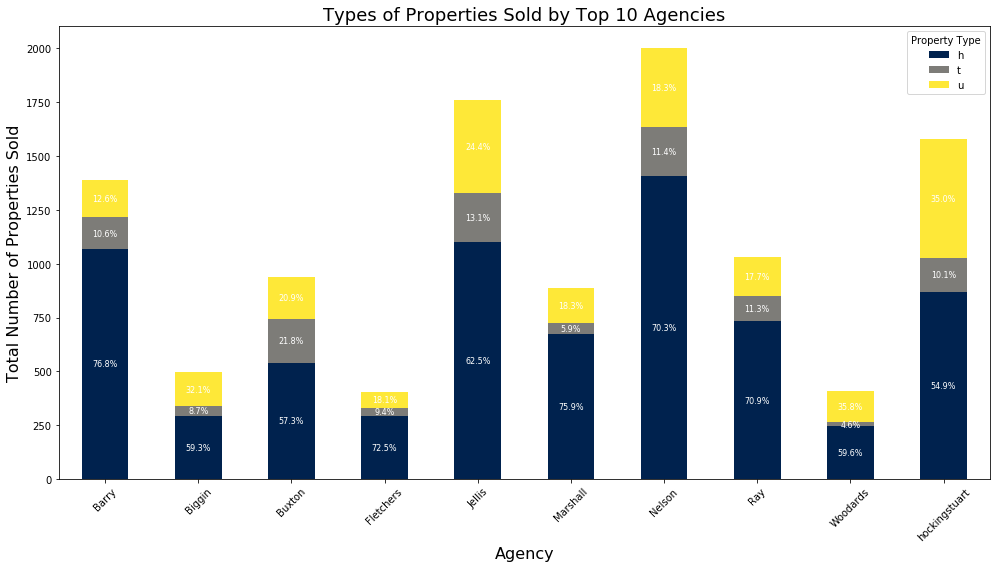

**Summary**:Agencies show varying levels of specialization in property types. For instance, Barry and Marshall have a higher percentage of houses sold, indicating a focus on suburban or family-oriented markets, whereas Hockingstuart and Jellis have a significant portion of units/apartments sold, suggesting a stronger presence in urban areas or a focus on investors or single professionals.

## 4. Property Prices

### 4.1 Price Distribution (Top 10)

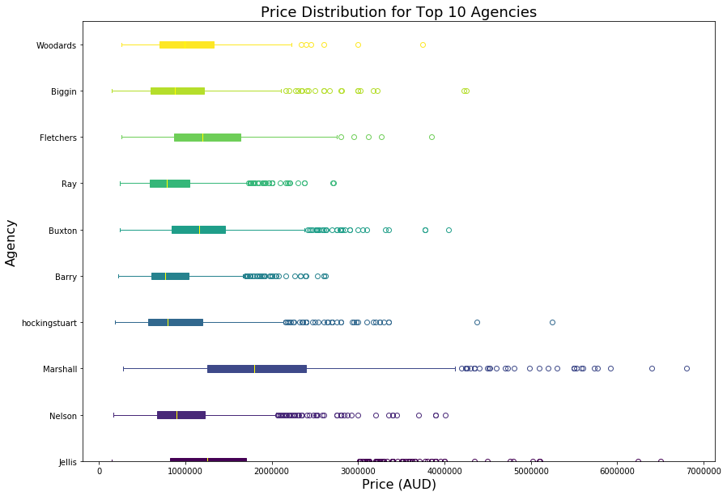

| SellerG | count | mean | std | min | 25% | 50% | 75% | max |
| --- | --- | --- | --- | --- | --- | --- | --- | --- |
| Barry | 1390.0 | 858261.0 | 357908.0 | 222000.0 | 609250.0 | 770000.0 | 1038750.0 | 2620000.0 |
| Biggin | 496.0 | 994709.0 | 557895.0 | 145000.0 | 600000.0 | 876000.0 | 1220000.0 | 4250000.0 |
| Buxton | 939.0 | 1215085.0 | 524975.0 | 240000.0 | 840000.0 | 1165000.0 | 1460000.0 | 4050000.0 |
| Fletchers | 403.0 | 1291125.0 | 571358.0 | 260000.0 | 872500.0 | 1200000.0 | 1641500.0 | 3851000.0 |
| Jellis | 1759.0 | 1354763.0 | 751660.0 | 145000.0 | 825000.0 | 1253000.0 | 1700000.0 | 6500000.0 |
| Marshall | 887.0 | 1911995.0 | 988350.0 | 280000.0 | 1250000.0 | 1800000.0 | 2400000.0 | 6800000.0 |
| Nelson | 2002.0 | 995317.0 | 466197.0 | 170000.0 | 672000.0 | 900000.0 | 1230000.0 | 4011000.0 |
| Ray | 1032.0 | 853259.0 | 373152.0 | 240000.0 | 590875.0 | 785000.0 | 1046250.0 | 2718000.0 |
| Woodards | 411.0 | 1034159.0 | 461222.0 | 260000.0 | 703000.0 | 991000.0 | 1325000.0 | 3750000.0 |
| hockingstuart | 1580.0 | 940028.0 | 520048.0 | 185000.0 | 572375.0 | 800000.0 | 1201625.0 | 5250000.0 |

**Summary**: Marshall sells significant high-value properties, followed by Jellis and Fletchers.

### 4.2 Price vs. Distance

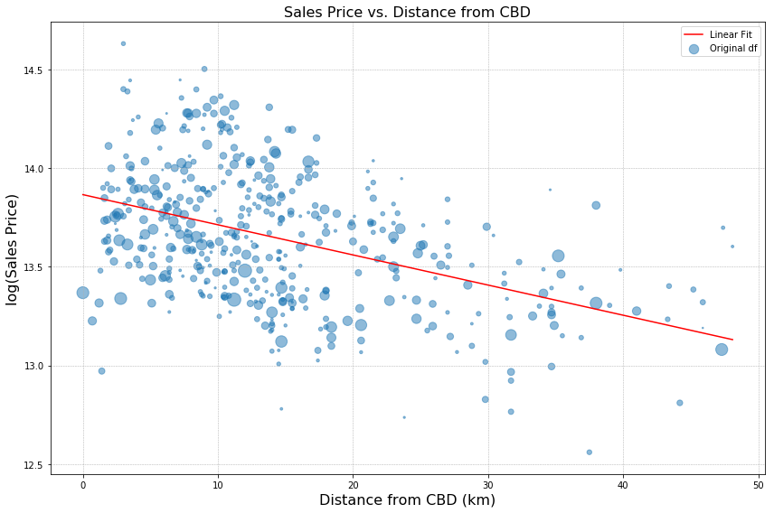

```
-0.015
```

**Summary**:

- Price vs. Distance Trend follows a common trend that property prices decrease as you move away from the city center. The slope of this line is -0.015, which is not really strong corrlation.
- The size of the bubbles indicates how many properties are in each suburb. Larger bubbles in areas closer to the CBD could suggest higher density or popularity,but the price sold are more in the lower side.

## 5 Heatmap

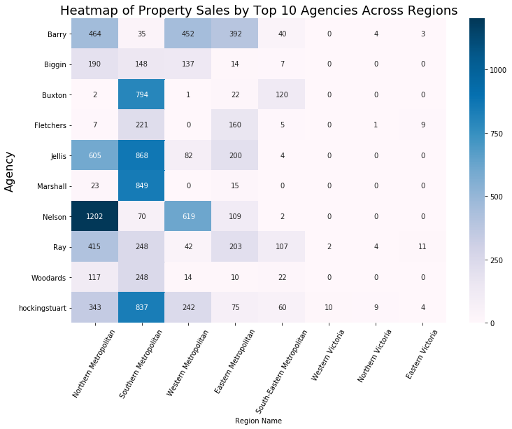

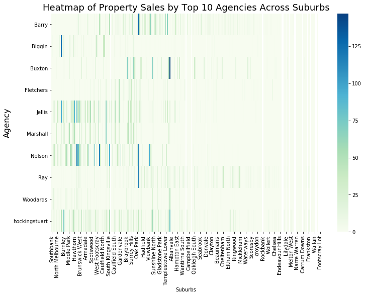

**Summary**: Different agencies focus on Different region/suburbs.

## 6.0 Performance Analysis and Conclusions

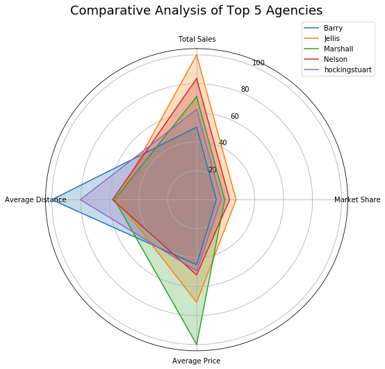

|  | SellerG | Total_Sales | Average_Price | Average_Distance | Market_Share |
| --- | --- | --- | --- | --- | --- |
| 0 | Barry | 50.061601 | 44.888237 | 100.000000 | 13.634366 |
| 1 | Jellis | 100.000000 | 70.856023 | 55.097772 | 27.235177 |
| 2 | Marshall | 71.167385 | 100.000000 | 56.688482 | 19.382564 |
| 3 | Nelson | 83.617326 | 52.056482 | 58.032321 | 22.773327 |
| 4 | hockingstuart | 62.325889 | 49.164769 | 80.240928 | 16.974566 |